# Part II - Prosper Loan Data Visualisation

## by Tobi A

## Investigation Overview

> This analysis is to help understand factors that determine the Prsoper loan’s outcome status and borrower's rate.

## Dataset Overview

> This is an exploratory data analysis of the loan data from Prosper. Prosper runs a website where individuals can either invest in personal loans or request to borrow money.

> The Prosper Loan data set contains 113,937 loans with 81 variables on each loan, including loan amount, borrower rate (or interest rate), current loan status, borrower income, and many others.

## Prosper Credit Rating

> Two ratings were assigned at the time the listing was created. The Credit rating for loans originated pre-2009 period and will only be populated for those while the Prosper Rating is for loans originated after July 2009. The two ratings are merged in order to have a wholistic view of Prosper's credit rating

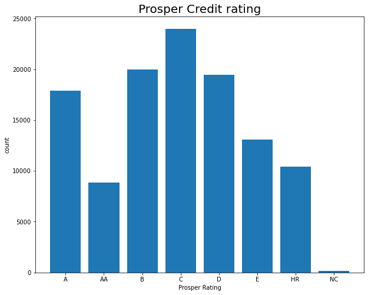

## Distribution of Income Range

> At a glance, we can see the what the borrowers earn and what range they fall into

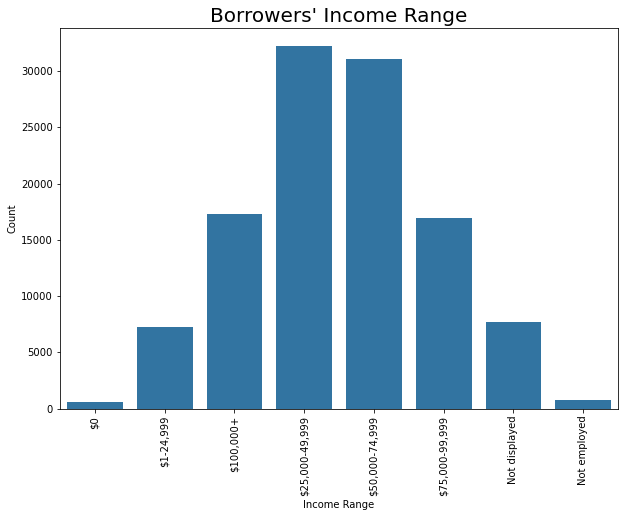

## How Income Range Affects Home Ownership

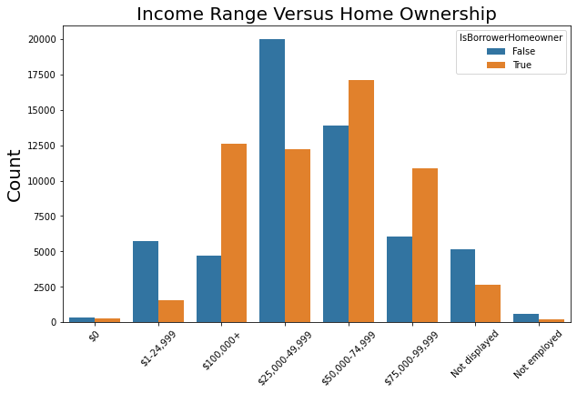

## Borrower's Rate As Affected by Prosper's Rating

> The relationship between the borrower's rate and prosper rating is very strong. Prosper's rating is a very great determinant to the borrower's rate. Borrower's with good credit rates get lower rates while customers with bad credit rates get higher rates as their risk is higher.

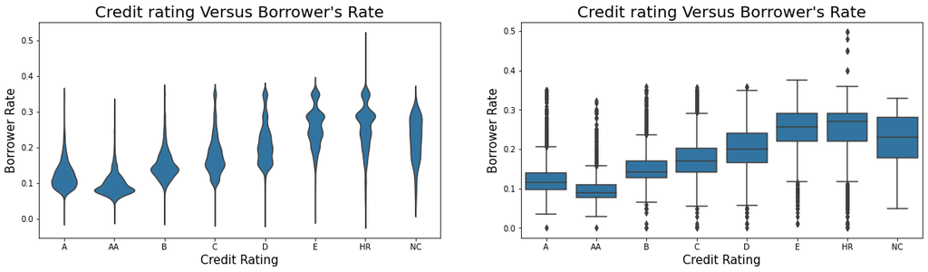

## Relationship Between LoanStatus, Borrower's Rate and Term

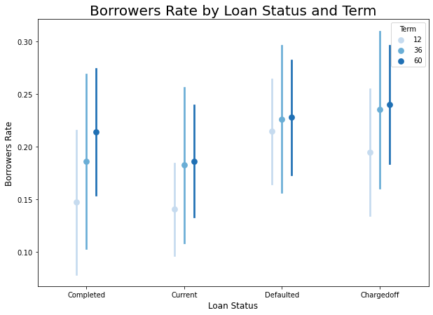